# Boats Segmentation: Drivers Analysis

**Aigerim Kulseitova, Grayden Reece-Smith, Julian Schroeder, Katherine Wilson, Jonathan Brugge**

## Business Decisions

CreeqBoat, a boating company, had become a victim of the crisis in the boating industry. While exploring various growth options it became apparent to the management that in order to expand in different markets it lacked customer insight. In particular for North America, the management believes that in order to develop expansion strategies they need to be able to segment the current customer base. He wants to segment his customer base into 5-10 groups for marketing purposes, based on factor analysis carried out in the previous session. The manager has told us that he has a boat design for every customer, his problem at the moment is getting people in the door. He has a marketing budget to advertise in several different channels, with the opportunity to emphasise different messages in different channels. We expect that customers are attracted by different attributes in boats and also by different emotions related to boating. The aim of the segmentation is to refine the message of CreeqBoat's marketing to attract groups in the population most likely to buy their boats. We know that some customers will not be easily convinced to visit a boat shop by an advertising campaign so we will also select target clusters to whom it will be easiest to market. When describing the clusters we will focus on the characteristics which we can use to target marketing. This report describes the process and results of the initial customer segmentation.

## The Data

Our input data consists of survey answers to a number of questions that relate to the type of boat that people might be interested in. Note that the respondents all have a boat: the survey therefore does not tell us anything about people who do not currently own a boat. The survey consists of 29 questions, each answered with an integer score between 1 and 5 inclusive.

We also have additional attribute and demographic data, which is also ranked on a metric scale but with different ranges of options. These attributes include information about current boat ownership, age and gender and income. Depending on the information the metric range is defined, e.g., gender is either 1 or 2, houshold income can range in categories between 1 and 19.

## Our Approach

#### Clustering and Segmentation in 8 steps

1. Confirm the data is metric
2. Decide whether to scale or standardize the data
3. Decide which variables to use for clustering
4. Define similarity or dissimilarity measures between observations
5. Visualize Individual Attributes and Pair-wise Distances between the Observations
6. Select the clustering method to use and decide how many clusters to have
7. Profile and interpret the clusters
8. Assess the robustness of our clusters

Let's follow these steps.

#### 2. Decide whether to scale or standardize the data

As mentioned in the introduction, the data collected is defined on different ranges. Hence we decided to scale the data to a mean of 0 and a standard deviation of 1.

```r
ProjectData_scaled = apply(ProjectData, 2, function(r) {
    if (sd(r) != 0)
        res = (r - mean(r))/sd(r) else res = 0 * r
    res
})
```

While this is typically a necessary step, one has to always do it with care: some times you may want your analytics findings to be driven mainly by a few attributes that take large values; other times having attributes with different scales may imply something about those attributes. In many such cases one may choose to skip step 2 for some of the raw attributes.

#### Step 3. Decide which variables to use for clustering

We started with our initial research question of finding characteristics of customer groups that CreeqBoat can use to develop, tailor and target its products and marketing towards. Based on our analysis, we selected six factors that help us to do so. Each factor can be described with a title, as well as with the statement from the questionnaire that is most closely related to that factor. These statements are also the variables that we used for clustering:

| 1 | The emotional experience seeker | Q21: Boating helps me escape from everyday life and relax |
| --- | --- | --- |
| 2 | The obsessed hobby boater | Q27: Boating is the number one thing I do with my spare time |
| 3 | The status seeker | Q9: I see my boat as a status symbol |
| 4 | The high quality seeker | Q4: I only consider buying a boat from a reputable brand |
| 5 | The price sensitive | Q12: When buying a boat, getting the lowest price is more important than the boat brand |
| 6 | The technician | Q11: I tend to perform minor boat repairs and maintenance on my own |

#### Step 4. Define similarity or dissimilarity measures between observations

In our case we explore two distance metrics: the commonly used **Euclidean distance** as well as a simple one we define manually.

Pairwise Distances between the first 5 observations using The Euclidean Distance Metric

| 1 | 2 | 3 | 4 | 5 |
| --- | --- | --- | --- | --- |
| 0.0 |  |  |  |  |
| 2.4 | 0.0 |  |  |  |
| 2.6 | 1.7 | 0.0 |  |  |
| 3.2 | 2.0 | 3.0 | 0.0 |  |
| 3.3 | 2.6 | 3.7 | 3.0 | 0.0 |

Notice for example that if we use, say, the Manhattan distance metric, these distances change as follows:

Pairwise Distances between the first 5 observations using The Manhattan Distance Metric

| 1 | 2 | 3 | 4 | 5 |
| --- | --- | --- | --- | --- |
| 0.0 |  |  |  |  |
| 6.0 | 0.0 |  |  |  |
| 5.0 | 3.0 | 0.0 |  |  |
| 6.0 | 4.0 | 5.0 | 0.0 |  |
| 5.0 | 5.0 | 8.0 | 7.0 | 0.0 |

Let's now define our own distance metric, as an example. Let's say that the management team of the company believes that two customers are similar if they do not differ in their ratings of the attitudinal questions by more than 2 points. We can manually assign a distance of 1 for every question for which two customers gave an answer that differs by more than 2 points, and 0 otherwise. It is easy to write this distance function in R:

```r
My_Distance_function <- function(x, y) {
    sum(abs(x - y) > 2)
}
```

Here is how the pairwise distances between the respondents now look like.

Pairwise Distances between the first 5 observations using a simple manually defined Distance Metric

| 1 | 2 | 3 | 4 | 5 |
| --- | --- | --- | --- | --- |
| 0.0 |  |  |  |  |
| 0.0 | 0.0 |  |  |  |
| 0.0 | 0.0 | 0.0 |  |  |
| 0.0 | 0.0 | 0.0 | 0.0 |  |
| 1.0 | 0.0 | 1.0 | 0.0 | 0.0 |

In general a lot of creative thinking and exploration should be spent in this step, and as always one may need to come back to this step even after finishing the complete segmentation process - multiple times.

#### Step 5. Visualize Individual Attributes and Pair-wise Distances between the Observations

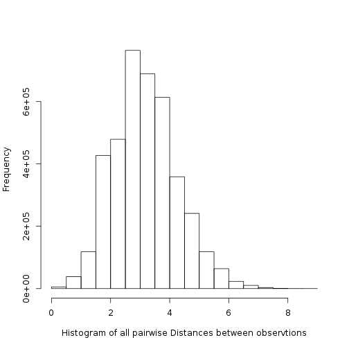

> Visualization is very important for data analytics, as it can provide a first understanding of the data.

#### Step 6. Select the clustering method to use and decide how many clusters to have

To answer the research question that we have posed, we have to derive a number of clusters of respondents who have provided answers to the questionnaire that are in some way related. It is important that the relationship of those answers is on dimensions that are relevant in answering our research question, which is about how to target the different customer segments. Intuitively, we would expect to end up with anywhere between five and ten segments. If there are less than five segments, it seems unlikely that most people within the segment share enough characteristics to allow us to reach them in a unified way. If there are more than ten segments, the number becomes so large that targeting each segment separately would be too much of an effort.

To arrive at the exact number of segments, we have experimented with a different numbers of clusters. Our decision finally depends on how well we are able to describe and target each segment in a distinctive way, while still allowing us limit the number of different segments that we have to adapt our marketing and sales approach for. Based on a number of iterations, we find that clustering in seven segments provides the balance that we are looking for.

In this note we will use two widely used methods: the **Kmeans Clustering Method**, and the **Hierarchical Clustering Method**. Like all clustering methods, these two also require that we have decided how to measure the distance/similarity between our observations. Explaining how these methods work is beyond our scope. The only difference to highlight is that Kmeans requires the user to define how many segments to create, while Hierarchical Clustering does not.

Let's fist use the **Hierarchial Clustering** method, as we do not know for now how many segments there are in our data. Hierarchical clustering is a method that also helps us visualise how the data may be clustering together. It generates a plot called the **Dendrogram** which is often helpful for visualization - but should be used with care. For example, in this case the dendrogram, using the euclidean distance metric from the earlier steps and the ward hierarchical clustering option (see below as well as help(hclust) in R for more information), is as follows:

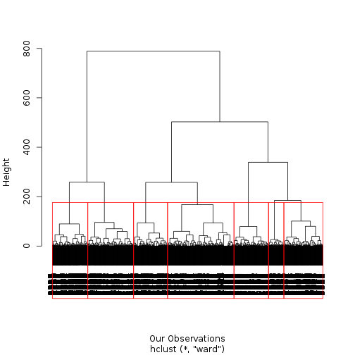

Note that we can draw as many clusters are we choose (e.g. in this case we chose 7 clusters) around the branches of the Dendrogram.

#### Step 7. Profile and interpret the clusters

In this step we are profiling and interpreting the clusters. After having seen in the previous step that we will select 7 clusters, our following analysis is concerned about the interpretation of these. In order to do so, we are using a two step approach. At first we will plot the average answers to the different questions by segment. Creating a snake plot of these different answers can already give us an indication whether our clusters are somewhat reasonable, i.e., whether we can see clear differences between the cluster lines of the snake plots. The second step of the analysis will identify the specific characteristics of the clusters. For this, we will plot each of the 81 questions and look at the average for each cluster to the average of the population. This will show us whether a specific cluster answers a question below or above average and will give us a deeper insight in how to characterize the customers allocated to this.

We can also “visualize” the segments using **snake plots** for each cluster. For example, we can plot the means of the profiling variables for each of our clusters to better visualize differences between segments. For better visualization we plot the standardized profiling variables.

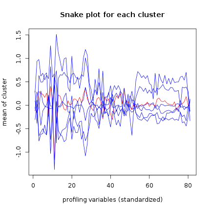

Can we see differences between the segments? Do the segments differ in terms of their average household income, gender and brand equity? What else can we say about these segments?

The above snake plots already indicate that our segmentation will be effective. We can see clear differences between the distinctness of the different segments in the first half of the questions (the questions regarding attitudes/needs/motivations) and the last third, the questions concerning demographics and brand equity. Further analysis of the different segments with regards to their average responses to each of the question relative to the average response of the total population will give us further insight on the specific characteristics of the segment. However, before analyzing the data, we need to remind that the values stated in the following table only compare the averages relative to the average of the population. If we for example see a segment with a score of 1.3 in the gender question, it does not mean that the segment consists of more men than women (Men = 1, Women = 2) since we are comparing the averages where the ratio of men to women across all segments should be stated as 1. Also it doesn't mean, that more women than men are in this segment. It might be that the survey was answered by 20% women and 80% men (although this is not the case here). A value of 1.3 in this case would just indicate that the segment has a higher share of women than the average of the surveyed population.

We can also compare the averages of the profiling variables of each segment relative to the average of the variables across the whole population. This can also help us better understand whether there are indeed clusters in our data (e.g. if all segments are much like the overall population, there may be no segments). For example, we can measure the ratios of the average for each cluster to the average of the population (e.g. avg(cluster)/avg(population)) and explore a matrix as the following one:

|  | Segment 1 | Segment 2 | Segment 3 | Segment 4 | Segment 5 | Segment 6 | Segment 7 |
| --- | --- | --- | --- | --- | --- | --- | --- |
| Q1_1_When buying a boat I do a lot of shopping around and visit multiple dealers | 0.9847 | 1.02 | 1.062 | 0.9863 | 1.057 | 0.9372 | 0.9747 |
| Q1_2_When buying a boat getting the lowest price is more important than the boat brand | 0.9441 | 0.9475 | 0.8638 | 1.101 | 1.33 | 1.009 | 1.041 |
| Q1_3_The brand of boat I buy says a lot about who I am | 1.098 | 0.988 | 1.209 | 1.007 | 1.32 | 0.7863 | 0.7492 |
| Q1_4_I only consider buying a boat from a reputable brand | 1.051 | 1.065 | 1.104 | 0.9091 | 1.131 | 0.8791 | 0.8701 |
| Q1_5_I am willing to pay a premium for a brand with a reputation for high quality | 1.062 | 1.017 | 1.13 | 0.9693 | 1.179 | 0.8697 | 0.8421 |
| Q1_6_Owning a boat is a way of rewarding myself for my hard work | 1.035 | 0.9954 | 1.135 | 0.9897 | 1.113 | 0.8779 | 0.9126 |
| Q1_7_Owning a boat gives me a sense of achievement | 1.064 | 0.9912 | 1.169 | 1.003 | 1.157 | 0.8452 | 0.8458 |
| Q1_8_When buying a boat functionality is more important than style | 0.9472 | 0.9885 | 0.9637 | 1.045 | 1.124 | 0.9753 | 1.048 |
| Q1_9_I see my boat as a status symbol | 1.152 | 0.9721 | 1.308 | 0.9933 | 1.475 | 0.7267 | 0.6144 |
| Q1_10_When buying a boat I rely more on expert opinion than my own e g consumer reports salespeople | 1.035 | 0.9875 | 0.9763 | 0.9956 | 1.166 | 1.016 | 0.9146 |
| Q1_11_I tend to perform minor boat repairs and maintenance on my own | 0.6106 | 1.143 | 1.225 | 1.164 | 1.224 | 0.5426 | 1.204 |
| Q1_12_When it comes to boating I tend to prefer a basic boat with little to no frills | 0.8769 | 0.8628 | 0.714 | 1.262 | 1.536 | 1.031 | 1.149 |
| Q1_13_When buying a boat I tend to buy the latest and greatest | 1.072 | 0.9904 | 1.185 | 0.9907 | 1.364 | 0.8256 | 0.7609 |
| Q1_14_When buying accessories for my boat I tend to buy the latest and greatest | 1.057 | 0.9989 | 1.196 | 0.9888 | 1.281 | 0.8141 | 0.8065 |
| Q1_15_I am serious about the technology on my boat | 1.011 | 1.02 | 1.158 | 1.005 | 1.178 | 0.8379 | 0.8681 |
| Q1_16_People tend to come to me for advice about boating | 0.9714 | 1.011 | 1.238 | 1.061 | 1.334 | 0.7375 | 0.8285 |
| Q1_17_I consider myself more knowledgeable about boating than the rest of my boating peers | 0.967 | 0.9978 | 1.199 | 1.083 | 1.321 | 0.7669 | 0.8494 |
| Q1_18_Boating gives me a feeling of adventure | 1.018 | 0.9954 | 1.109 | 0.9746 | 1.069 | 0.9277 | 0.9477 |
| Q1_19_Boating allows me to experience nature | 1.001 | 0.9958 | 1.082 | 0.9723 | 1.051 | 0.9536 | 0.98 |
| Q1_20_When not on my boat I often find myself doing boating related activities | 1.009 | 0.9878 | 1.203 | 1.062 | 1.322 | 0.7759 | 0.8209 |
| Q1_21_Boating helps me escape from everyday life and relax | 1.023 | 0.9873 | 1.117 | 0.9482 | 1.077 | 0.9234 | 0.9799 |
| Q1_22_Boating helps me stay active | 1.024 | 1.001 | 1.11 | 0.9909 | 1.088 | 0.8922 | 0.9362 |
| Q1_23_Boating allows me to excel in the sports that I am passionate about e g fishing racing water sports | 1.021 | 1.00 | 1.164 | 1.027 | 1.173 | 0.8328 | 0.8697 |
| Q1_24_Boating gives me an outlet to socialize with family and or friends | 1.031 | 1.00 | 1.102 | 0.9717 | 1.066 | 0.9234 | 0.9356 |
| Q1_25_Being in charge of my boat is very important to me | 1.011 | 1.002 | 1.158 | 1.016 | 1.146 | 0.825 | 0.9191 |
| Q1_26_Having a powerful boat is what is most important to me | 1.086 | 0.9704 | 1.219 | 1.042 | 1.364 | 0.802 | 0.7124 |
| Q1_27_Boating is the number one thing I do with my spare time | 1.124 | 0.8909 | 1.337 | 1.128 | 1.396 | 0.7479 | 0.64 |
| Q1_28_Boating is my true passion in life | 1.041 | 0.9666 | 1.237 | 1.058 | 1.317 | 0.81 | 0.7577 |
| Q1_29_Boating is one of many things I do in my spare time | 1.007 | 0.995 | 1.073 | 1.004 | 1.086 | 0.9158 | 0.9721 |
| Q2_How many powerboats do you currently own | 0.9558 | 0.9778 | 1.048 | 1.063 | 1.283 | 0.851 | 1.009 |

[output cut: 51 more lines]

#### Step 8. Assess the robustness of our clusters

We will skip this step for this exercise. However in practice this is a very important step.

## Intepretation, Decisions and Conclusion

We have followed a structured process to answer our initial research question, which is about how to tailor messages in different marketing channels to specific groups of customers. To answer this question, we have clustered boat owners in seven clearly distinct segments. Each of those segments has characteristics that allow us to target them in a tailored way:

[output not shown]

We conclude that segments 1, 2 and 4 are most likely to be appealing to us, so our marketing investments would be focused on these segments. With the remaining budget, we would attempt to reach groups 6 and 7 as well. We are unlikely to invest in segments 3 and 5.